# ISOM 2600 Assignment 2

In this assignment project, you will be acting as a data analyst of a Californian housing agency. You will be responsible to analyze the data of houses from all over the state of California and create a prediction model for house values.

The total score of this assignment is 65 points.

## **Instructions:**

For each question, please directly add one or more boxes of code or text under each question to accomplish each task.

Use code boxes to show your code and provide your answers in separate text boxes. Some questions require more than one output to be shown.

**Answers provided in code comments won't be graded.**

**Students not listed in the author list will receive 0 marks.**

**Failing to submit the html file will result in 1 mark deduction per question. Same penalty applies if the code in the submission has not been executed.**

**Failing to submit the ipynb file will result in marks deducted for the code portion of each question. The same will apply if the code breaks or produces different results from what is displayed in the html version.**

**Late submissions will receive 0 marks**

## Authors

```python
Shek Tsz Lung 21174335
```

## Part I: Preprocessing on Data

```python
import pandas as pd
import numpy as np
import seaborn as sns
import scipy.stats as stats
import statsmodels.api as sm
import matplotlib.pyplot as plt
plt.style.use('ggplot')
import warnings
warnings.filterwarnings('ignore')
from sklearn.datasets import fetch_california_housing
```

We are using a dataset provided by scikit learn called California Housing. Run the code below to load the dataset.

```python
housing_df = fetch_california_housing(as_frame=True).frame
housing_df.head()
```

|  | MedInc | HouseAge | AveRooms | AveBedrms | Population | AveOccup | Latitude | Longitude | MedHouseVal |
| --- | --- | --- | --- | --- | --- | --- | --- | --- | --- |
| 0 | 8.3252 | 41.0 | 6.984127 | 1.023810 | 322.0 | 2.555556 | 37.88 | -122.23 | 4.526 |
| 1 | 8.3014 | 21.0 | 6.238137 | 0.971880 | 2401.0 | 2.109842 | 37.86 | -122.22 | 3.585 |
| 2 | 7.2574 | 52.0 | 8.288136 | 1.073446 | 496.0 | 2.802260 | 37.85 | -122.24 | 3.521 |
| 3 | 5.6431 | 52.0 | 5.817352 | 1.073059 | 558.0 | 2.547945 | 37.85 | -122.25 | 3.413 |
| 4 | 3.8462 | 52.0 | 6.281853 | 1.081081 | 565.0 | 2.181467 | 37.85 | -122.25 | 3.422 |

### **Question 1:** Data analysis

#### 1. Understanding the data [5]

Use following code to understand more about the dataset:

```
    print(california_housing.DESCR)
```

The value we would like to predict is the **Median House Value**.

After this initial analysis, which 2 variables would you assume are highly correlated (non-linearly) and why? We will ignore these 2 variables in the next step.

```python
california_housing = fetch_california_housing()
print(california_housing.DESCR)
#median
housing_df["MedHouseVal"].median()
```

```
.. _california_housing_dataset:

California Housing dataset
--------------------------

**Data Set Characteristics:**

:Number of Instances: 20640

:Number of Attributes: 8 numeric, predictive attributes and the target

:Attribute Information:
    - MedInc        median income in block group
    - HouseAge      median house age in block group
    - AveRooms      average number of rooms per household
    - AveBedrms     average number of bedrooms per household
    - Population    block group population
    - AveOccup      average number of household members
    - Latitude      block group latitude
    - Longitude     block group longitude

:Missing Attribute Values: None

This dataset was obtained from the StatLib repository.
https://www.dcc.fc.up.pt/~ltorgo/Regression/cal_housing.html

The target variable is the median house value for California districts,
expressed in hundreds of thousands of dollars ($100,000).

This dataset was derived from the 1990 U.S. census, using one row per census
block group. A block group is the smallest geographical unit for which the U.S.
Census Bureau publishes sample data (a block group typically has a population
of 600 to 3,000 people).

A household is a group of people residing within a home. Since the average
number of rooms and bedrooms in this dataset are provided per household, these
columns may take surprisingly large values for block groups with few households
and many empty houses, such as vacation resorts.

It can be downloaded/loaded using the
:func:`sklearn.datasets.fetch_california_housing` function.

.. rubric:: References

- Pace, R. Kelley and Ronald Barry, Sparse Spatial Autoregressions,
  Statistics and Probability Letters, 33 (1997) 291-297
```

```
1.797
```

The Longitude and Latitude are highly correlated variables as all housing in that area should have the same Longitude and Latitude.

#### 2. Visualizing the data [5]

Plot the scatter matrix between the **remaining** variables. Are there any preliminary insights we can gain from this?

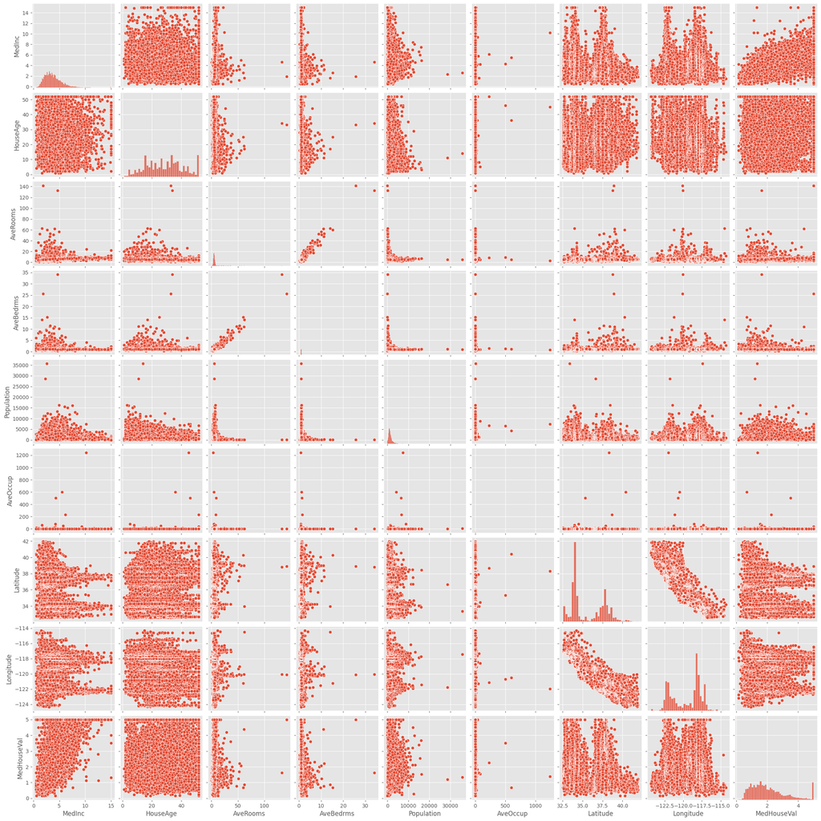

```python
housing_df.drop(columns = ['Latitude','Longitude']) #drop two highly correlated variables
sns_plot = sns.pairplot(housing_df)
plt.show()
```

#### 3. Geographical Information [5]

Complete and use this code to generate a map of the locations, highlighting median house values. Replace "-var-n-" with the correct variable names:

```
sns.scatterplot(
    data=housing_df.iloc[housing_df.index],
    x="-var-1-",
    y="-var-2-",
    size="-var-3-",
    hue="-var-3-",
    palette="viridis",
    alpha=0.5,
)
plt.legend(title="MedHouseVal", bbox_to_anchor=(1.05, 0.95), loc="upper left")
```

What insights can you gain from this graph? Are these variables an important predictor? Why?

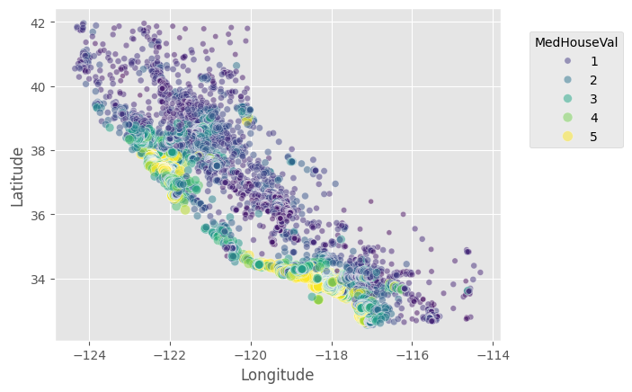

```python
sns.scatterplot(
    data = housing_df.iloc[housing_df.index],
    x = "Longitude",      #geographic variables
    y = "Latitude",       #geographic variables
    size = "MedHouseVal",    #housing value
    hue = "MedHouseVal",    #housing value
    palette = "viridis",
    alpha = 0.5,
)
plt.legend(title="MedHouseVal", bbox_to_anchor=(1.05, 0.95), loc="upper left")
```

high value homes (MedHouseVal) are concentrated along the coast, inland areas show lower house values

## Part II: Regression Analysis

Based on the data we've collected, we would like to conduct a regression analysis and make a prediction on the Median Market Value of the houses

### **Question 2**: Build the Regression model

#### 1. Split the data into train (80%) and test (20%) set （Set the random seed = 1500）and show the shape of both sets. Which value do they have in common? [5]

```python
train=housing_df.sample(frac=0.8, random_state=1500)  #training data set with random seed = 1500
test=housing_df.drop(train.index)            #rest data are testing data
print(train.shape)
print(test.shape)
```

```
(16512, 9)
(4128, 9)
```

#### 2. Define the dependent variable and independent variables variables in train set [5]

```python
Y=train['MedHouseVal']
X=train.drop(columns="MedHouseVal")
```

#### 3. Build up the regression model with train set [5]

```python
full_model =sm.OLS(Y, sm.add_constant(X)).fit()
print(full_model.summary())
```

```
                            OLS Regression Results
==============================================================================
Dep. Variable:            MedHouseVal   R-squared:                       0.603
Model:                            OLS   Adj. R-squared:                  0.602
Method:                 Least Squares   F-statistic:                     3129.
Date:                Thu, 04 Dec 2025   Prob (F-statistic):               0.00
Time:                        13:20:49   Log-Likelihood:                -18145.
No. Observations:               16512   AIC:                         3.631e+04
Df Residuals:                   16503   BIC:                         3.638e+04
Df Model:                           8
Covariance Type:            nonrobust
==============================================================================
                 coef    std err          t      P>|t|      [0.025      0.975]
------------------------------------------------------------------------------
const        -37.0592      0.738    -50.224      0.000     -38.506     -35.613
MedInc         0.4323      0.005     92.651      0.000       0.423       0.441
HouseAge       0.0093      0.001     18.659      0.000       0.008       0.010
AveRooms      -0.0997      0.006    -15.367      0.000      -0.112      -0.087
AveBedrms      0.6100      0.031     19.853      0.000       0.550       0.670
Population -4.039e-06   5.22e-06     -0.774      0.439   -1.43e-05    6.18e-06
AveOccup      -0.0034      0.000     -6.998      0.000      -0.004      -0.002
Latitude      -0.4239      0.008    -52.580      0.000      -0.440      -0.408
Longitude     -0.4364      0.008    -51.719      0.000      -0.453      -0.420
==============================================================================
Omnibus:                     3583.068   Durbin-Watson:                   2.005
Prob(Omnibus):                  0.000   Jarque-Bera (JB):            11988.819
Skew:                           1.088   Prob(JB):                         0.00
Kurtosis:                       6.563   Cond. No.                     2.40e+05
==============================================================================

Notes:
[1] Standard Errors assume that the covariance matrix of the errors is correctly specified.
[2] The condition number is large, 2.4e+05. This might indicate that there are
strong multicollinearity or other numerical problems.
```

#### 4. Which predictor is the most insignificant one? Why? [5]

```python
Population, it has high p-value, 0.439
```

#### 5. What is the impact of one extra room on the average median value of homes? Does the coefficient surprice you? Why? [5]

```python
The coefficient of AveRooms is -0.0997, which means, when the rooms number increases by 1 unit, the median house value decreases by -0.0997. Which is abnormal
```

[output not shown]

### **Question 3**: *Residual Analysis*

#### 1. Create the residual plot using train set (4 plots in 1). What can you say about the Q-Q plot? [5]

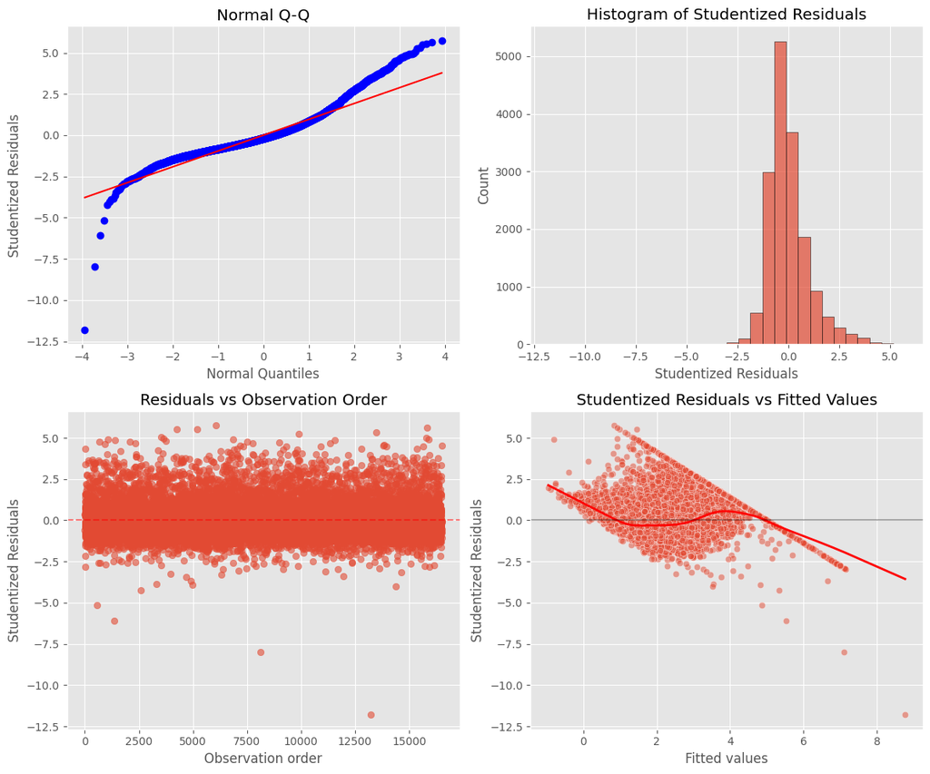

```python
def four_in_one(dataframe,model):
  fitted_y = model.fittedvalues
  studentized_residuals = model.get_influence().resid_studentized_internal

  plt.figure(figsize=(12, 10))

  # 1. Q-Q Plot
  ax1 = plt.subplot(221)
  stats.probplot(studentized_residuals, dist="norm", plot=plt)
  ax1.set_title('Normal Q-Q')
  ax1.set_xlabel('Normal Quantiles')
  ax1.set_ylabel('Studentized Residuals')

  # 2. Histogram
  ax2 = plt.subplot(222)
  ax2.hist(studentized_residuals, bins=30, edgecolor='black', alpha=0.7)
  ax2.set_xlabel('Studentized Residuals')
  ax2.set_ylabel('Count')
  ax2.set_title('Histogram of Studentized Residuals')

  # 3. Time series plot
  ax3 = plt.subplot(223)
  t = np.arange(len(studentized_residuals))
  ax3.scatter(t, studentized_residuals, alpha=0.6)
  ax3.axhline(y=0, color='red', linestyle='--', alpha=0.5)
  ax3.set_xlabel('Observation order')
  ax3.set_ylabel('Studentized Residuals')
  ax3.set_title('Residuals vs Observation Order')

  # 4. Residuals vs Fitted values using seaborn
  ax4 = plt.subplot(224)
  temp = pd.DataFrame({
      'fitted_y': fitted_y,
      'studentized_residuals': studentized_residuals
  })

  # For newer seaborn versions, use scatterplot and lowess manually
  sns.scatterplot(data=temp, x='fitted_y', y='studentized_residuals',
                  alpha=0.5, ax=ax4)

  # Add LOWESS line
  import statsmodels.api as sm
  lowess = sm.nonparametric.lowess
  z = lowess(temp['studentized_residuals'], temp['fitted_y'], frac=0.3)
  ax4.plot(z[:, 0], z[:, 1], color='red', linewidth=2, label='LOWESS')

  ax4.axhline(y=0, color='black', linestyle='-', alpha=0.3)
  ax4.set_title('Studentized Residuals vs Fitted Values')
  ax4.set_xlabel('Fitted values')
  ax4.set_ylabel('Studentized Residuals')

  plt.tight_layout()
  plt.show()
four_in_one(train, full_model)
```

The Q-Q plot does not show a linear relationship of residual, which means the residual are not normal distributed (the assumption is violated)

#### 2. Although only one variable seems quite insignificant, we want to focus on only four variables: Median Income, Latitude, Longitude, and Average number of Bedrooms because of strong colinearity. Create the corresponding reduced regression model [5]

```python
to_drop=["MedHouseVal", 'Population', 'HouseAge', 'AveRooms', 'AveOccup']
x_reduced=train.drop(columns=to_drop)
reduced_model=sm.OLS(Y, sm.add_constant(x_reduced)).fit()
print(reduced_model.summary())
```

```
                            OLS Regression Results
==============================================================================
Dep. Variable:            MedHouseVal   R-squared:                       0.586
Model:                            OLS   Adj. R-squared:                  0.586
Method:                 Least Squares   F-statistic:                     5840.
Date:                Thu, 04 Dec 2025   Prob (F-statistic):               0.00
Time:                        13:21:03   Log-Likelihood:                -18485.
No. Observations:               16512   AIC:                         3.698e+04
Df Residuals:                   16507   BIC:                         3.702e+04
Df Model:                           4
Covariance Type:            nonrobust
==============================================================================
                 coef    std err          t      P>|t|      [0.025      0.975]
------------------------------------------------------------------------------
const        -43.5845      0.706    -61.702      0.000     -44.969     -42.200
MedInc         0.3670      0.003    116.397      0.000       0.361       0.373
AveBedrms      0.1677      0.012     14.115      0.000       0.144       0.191
Latitude      -0.5044      0.007    -67.367      0.000      -0.519      -0.490
Longitude     -0.5187      0.008    -65.399      0.000      -0.534      -0.503
==============================================================================
Omnibus:                     3783.905   Durbin-Watson:                   2.010
Prob(Omnibus):                  0.000   Jarque-Bera (JB):            10085.063
Skew:                           1.231   Prob(JB):                         0.00
Kurtosis:                       5.931   Cond. No.                     1.53e+04
==============================================================================

Notes:
[1] Standard Errors assume that the covariance matrix of the errors is correctly specified.
[2] The condition number is large, 1.53e+04. This might indicate that there are
strong multicollinearity or other numerical problems.
```

### **Question 4**: *Model Performance Evaluation*

#### 1. Predict the value of Y in test set using full and reduced model [5]

```python
Test_X_full=test.drop(columns="MedHouseVal")
Test_X_reduced=test.drop(columns=to_drop)

Test_Y_full=full_model.predict(sm.add_constant(Test_X_full))
Test_Y_reduced=reduced_model.predict(sm.add_constant(Test_X_reduced))
Test_Y_reduced
```

|  | 0 |
| --- | --- |
| 0 | 3.934584 |
| 6 | 2.240654 |
| 9 | 2.258947 |
| 13 | 1.908735 |
| 16 | 1.937809 |
| ... | ... |
| 20618 | 0.768917 |
| 20627 | 0.891019 |
| 20630 | 1.024063 |
| 20632 | 0.935200 |
| 20635 | 0.072179 |

4128 rows × 1 columns

**dtype:** float64

#### 2. Compute the RMSE of full and reducted model using test set. [5]

```python
Test_Y=test["MedHouseVal"]

from sklearn.metrics import mean_squared_error
rmse_full=np.sqrt(mean_squared_error(Test_Y, Test_Y_full))
rmse_reduced=np.sqrt(mean_squared_error(Test_Y, Test_Y_reduced))
print("RMSE for test set (Full Model):", rmse_full)
print("RMSE for test set (Reduced Model):", rmse_reduced)
```

```
RMSE for test set (Full Model): 0.7162383599409242
RMSE for test set (Reduced Model): 0.7355285868871193
```

#### 3. Based on the Adjusted R squared and RMSE, which model has better performance. [5]

The full_model has a higher Adjusted R squared and full_model has the lower RMSE, so, the full_model has better performance

## Convert ipynb to HTML in Colab (required)

**You are required to submit both ipynb and HTML formats on canvas.**

The HTML version allows us to see that results you generated on your machine.

The ipynb version will be used to replicate your results. If we cannot replicate the results, or if the code breaks, marks will be deducted.

Instruction:

1. Download the ipynb, which you want to convert, on your local computer.
2. Run the code below to upload the ipynb.

The html version will be downloaded automatically on your local machine.

```python
# Upload ipynb
from google.colab import files
f = files.upload()

# Convert ipynb to html
import subprocess
file0 = list(f.keys())[0]
_ = subprocess.run(["pip", "install", "nbconvert"])
_ = subprocess.run(["jupyter", "nbconvert", file0, "--to", "html"])

# download the html
files.download(file0[:-5]+"html")
```

```
Saving Assignment_2_Fall25_(final).ipynb to Assignment_2_Fall25_(final).ipynb
```